# Least Squares Regression

M Loecher

Load the Advertising data set

```r
Advertising <- read.csv("../../data/Advertising.csv", row.names=1)
```

and write a function that creates a scatter plot each of Sales versus one of the three other variables and overlays the mean:

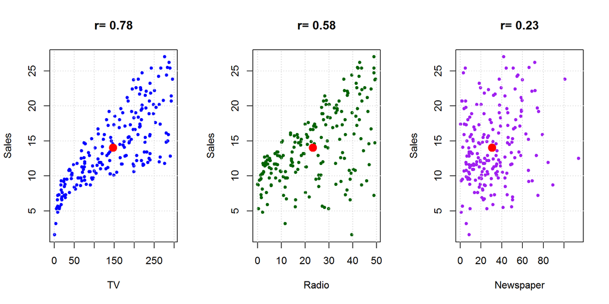

```r
r = round(cor(Advertising),2)
m = colMeans(Advertising)

plotAds = function(x="TV", myData=Advertising, col = "blue",m=m){
  plot(myData[,x], myData$Sales, pch=20, col = col, xlab = x, ylab = "Sales");grid();
  title(paste("r=", round(cor(myData[,x], myData$Sales),2)))
  m = colMeans(Advertising[,c(x,"Sales")])
  points(m[x],m["Sales"], col="red",pch=19,cex=1.75)
}

par(mfrow=c(1,3),cex=1)
plotAds("TV")
plotAds("Radio", col = "darkgreen")
plotAds("Newspaper", col = "purple")
```

#### Review: Straight Line Equation

Let us recall that a straight line can be defined either by just two points or by its slope and intercept:
$$y = m \cdot x + b \mbox{, or more fancy: } y = \beta_1 \cdot x + \beta_0$$
The slope is simply $\beta_1 = \Delta y/\Delta x$.

Given two points $(x_1,y_1), (x_2,y_2)$ please derive the expressions that yield $\beta_1$ and $\beta_0$.

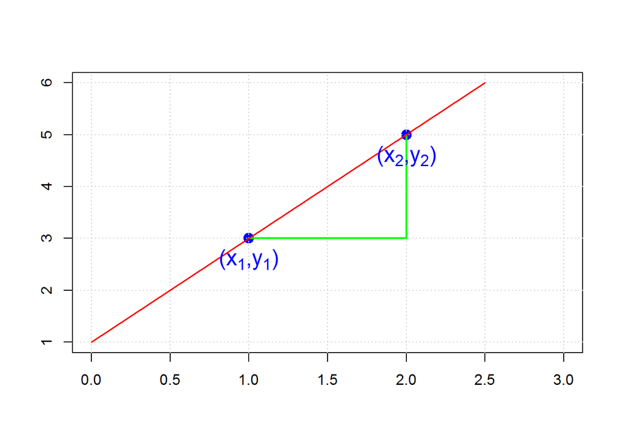

$$\beta_1 = \frac{\Delta y}{\Delta x} = \frac{y_2-y_1}{x_2-x_1}$$

#### Task 1. Write a function that takes as input two points and returns the slope and intercept.

```r
LineEqn = function(p1=c(1,2), p2=c(3,5)){
  dY = p2[2]-p1[2]
  dX = p2[1]-p1[1]
  m=dY/dX
  b=p2[2] - m*p2[1]
  return(c(m,b))
}

LineEqn()
```

```
## [1] 1.5 0.5
```

```r
LineEqn2 = function(x=c(1,3), y=c(2,5)){
  dY = diff(y)
  dX = diff(x)
  m=dY/dX
  b=y[2] - m*x[2]
  return(c(m,b))
}
```

#### Task 2. Eyeball a point on the far left or far right of the graph. Take this point as well as the mean as an in put to the function from above to get a slope and intercept. Modify the function from above to overlay a line with these parameters.

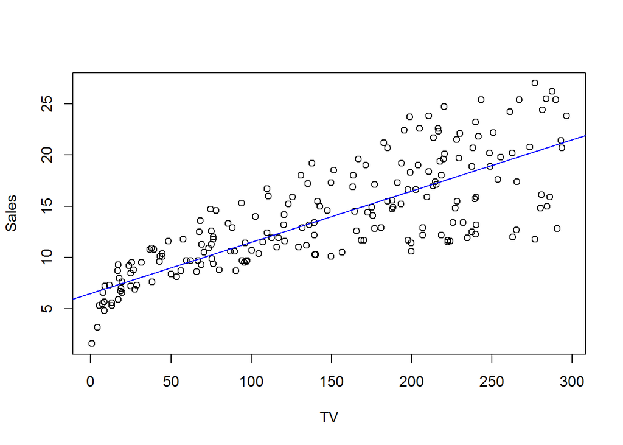

```r
plot(Sales ~ TV, data = Advertising)

mb=LineEqn2(x=c(50,150), y=c(9,14))

abline(mb[2],mb[1], col = "blue")
```

```r
#myFirstModel = lm(Sales ~ TV, data = Advertising)
#abline(myFirstModel, col = 2)

#summary(myFirstModel)
```

### Covariance, Correlation

$$COV = s_{xy} = \frac{1}{n} \cdot \sum_{i=1}^{n} {(x_i- \bar{x})(y_i- \bar{y})}$$

$$s_{xy} = \overline{x \cdot y} - \bar{y} \cdot \bar{x}$$

$$r = \frac{s_{xy}}{s_x s_y} = \frac{\frac{1}{n} \cdot \sum_{i=1}^{n} {(x_i- \bar{x})(y_i- \bar{y})}}{\sqrt{\frac{1}{n} \cdot \sum_{i=1}^{n} {(x_i- \bar{x})^2}} \sqrt{\frac{1}{n} \cdot \sum_{i=1}^{n} {(y_i- \bar{y})^2}} }$$
$$= \frac{\frac{1}{n} \ldots}{\sqrt{\frac{1}{n} \ldots} \sqrt{\frac{1}{n} \ldots}}$$
#### Task 3. Compute the “best” slope

```r
#best slope: cov/var

beta1 = cov(Advertising$TV,Advertising$Sales)/var(Advertising$TV )
beta0 = mean(Advertising$Sales) - beta1*mean(Advertising$TV)
```

#### Task 5. Verify the least squares property of the regression line

```r
myYhat = 6.5 + 0.05*Advertising$TV
mye = Advertising$Sales - myYhat
myRSS = sum(mye^2)

myRSS
```

```
## [1] 2117.237
```

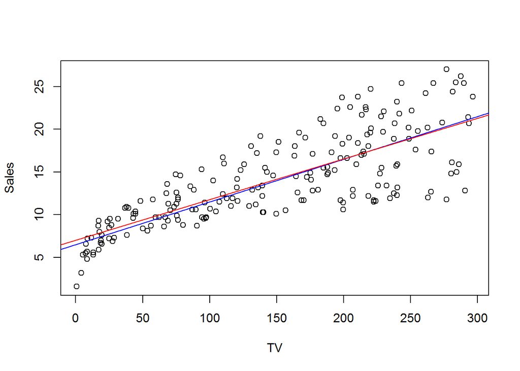

```r
plot(Sales ~ TV, data = Advertising)

mb=LineEqn2(x=c(50,150), y=c(9,14))

abline(mb[2],mb[1], col = "blue")
myFirstModel = lm(Sales ~ TV, data = Advertising)
abline(myFirstModel, col = 2)
```

#### Task 6. Looking at Sales alone, what is your best “prediction” and what is the unvertainty that goes with it, expressed in two different ways.

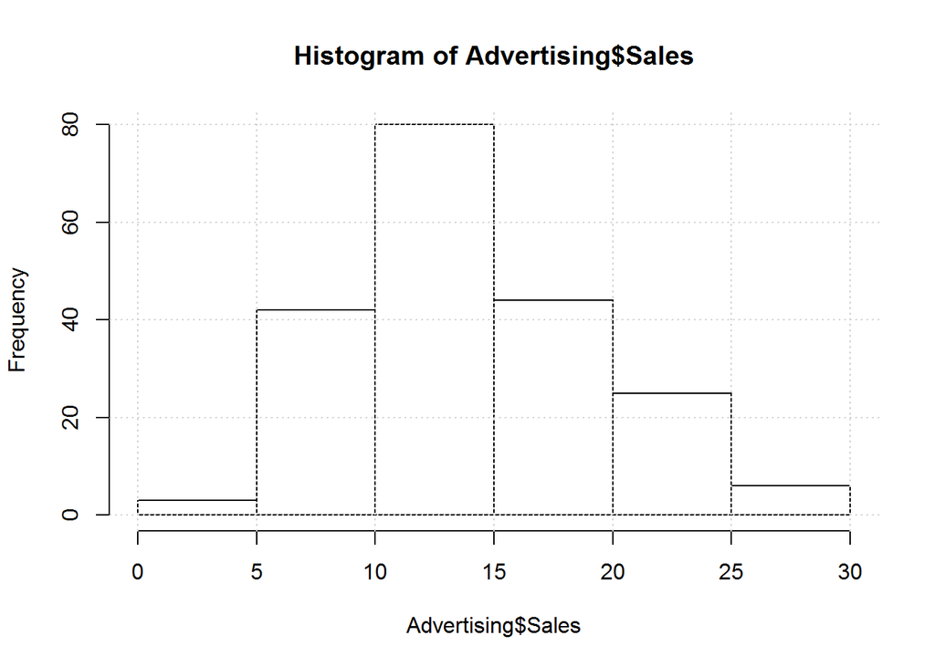

```r
hist(Advertising$Sales);grid()
```

#### Task 7. What is the remaning uncertainty “after the regression”?

```r
summary(myFirstModel)
```

```
##
## Call:
## lm(formula = Sales ~ TV, data = Advertising)
##
## Residuals:
##     Min      1Q  Median      3Q     Max
## -8.3860 -1.9545 -0.1913  2.0671  7.2124
##
## Coefficients:
##             Estimate Std. Error t value Pr(>|t|)
## (Intercept) 7.032594   0.457843   15.36   <2e-16 ***
## TV          0.047537   0.002691   17.67   <2e-16 ***
## ---
## Signif. codes:  0 '***' 0.001 '**' 0.01 '*' 0.05 '.' 0.1 ' ' 1
##
## Residual standard error: 3.259 on 198 degrees of freedom
## Multiple R-squared:  0.6119, Adjusted R-squared:  0.6099
## F-statistic: 312.1 on 1 and 198 DF,  p-value: < 2.2e-16
```